# meth02_analyze_data.R

heissj01

2019-04-30

# Analyze methylation data

Using data preprocessed in our script:  
meth01_process_data.R

Local library

```r
.libPaths("C:/EBC3/Rpackages")
knitr::opts_knit$set(root.dir = "../")
```

we have a processed dataset with 30 samples (otherwise we run script 01)

```r
#if(!exists("data/processed.rds")){
#  source("code/meth01_process_data.R")
#}

# load the data
load("data/processed.rda")
```

load packages

```r
suppressPackageStartupMessages({
  library(DMRcate) # for regional analysis
  library(magrittr)
  library(CpGassoc) # for running association analysis between methylation levels values and phenotype of interest
  library(data.table) # for fast aggregation of large data
  library(qqman) # for visualization of data
  library(stringi) # string manipulation
})
```

Code categorical variable as factors

```r
pheno$smoker %<>% factor
pheno$sex    %<>% factor

## Cleaning up the methylation data
```

```r
dim(beta)
```

```
## [1] 485577     30
```

```r
betas.clean = beta[manifest[probe_type=="cg" & !chr %in% c("X","Y")]$index,]
nCpG = dim(betas.clean)[1]
nCpG
```

```
## [1] 470870
```

# Running an Epigenome Wide Association

Here we run an EWAS on Smoking status (as a predictor of methylation)  
First we can run a linear regression on a single CpG that we have already picked

```r
CpG.name = "cg05575921"
pheno$CpG.level <- betas.clean[CpG.name,]
```

Difference in methylation between smokers and non-smokers for this CpG some descriptive statistics

```r
pheno[,.(
   Min    = min   (CpG.level) %>% round(3)
  ,Mean   = mean  (CpG.level) %>% round(3)
  ,Median = median(CpG.level) %>% round(3)
  ,Max    = max   (CpG.level) %>% round(3)
  ,SD     = sd    (CpG.level) %>% round(3)
  ,.N),by=smoker] %>% knitr::kable(.)
```

| smoker | Min | Mean | Median | Max | SD | N |
| --- | --- | --- | --- | --- | --- | --- |
| smoker | 0.399 | 0.543 | 0.529 | 0.780 | 0.107 | 15 |
| non-smoker | 0.805 | 0.855 | 0.865 | 0.884 | 0.023 | 15 |

Difference in beta methylation values between Smokers and non smokers

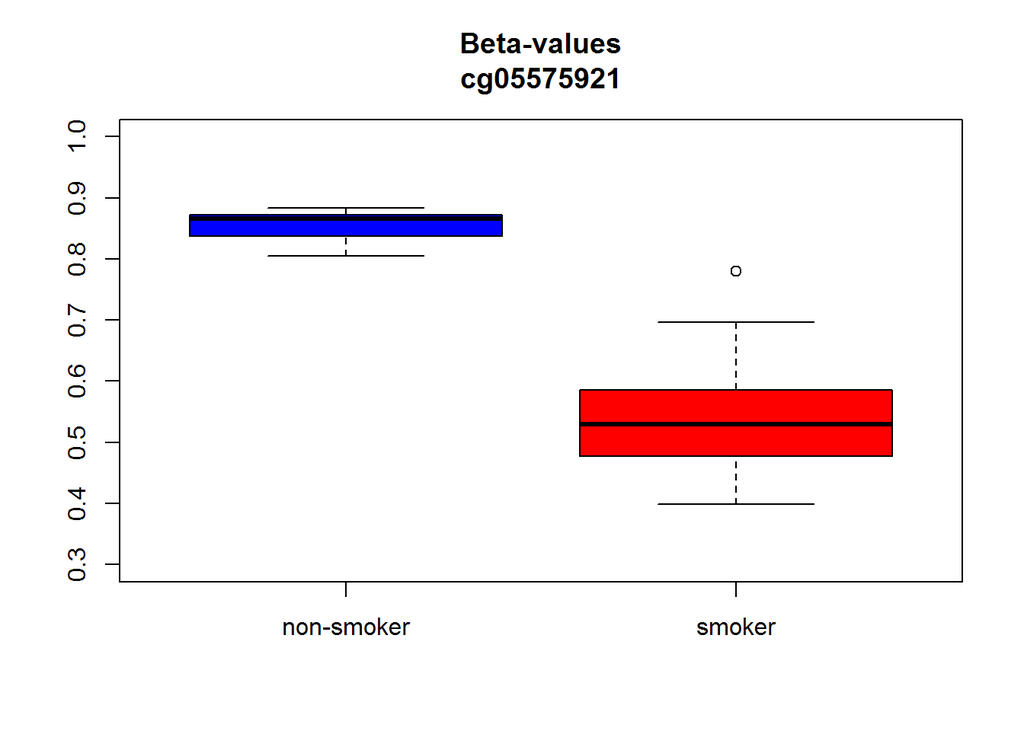

```r
boxplot(CpG.level ~ smoker,pheno,main=paste0("Beta-values\n", CpG.name), col=c("blue","red"),ylim=c(.3,1))
```

Linear regression on betas

```r
lm(CpG.level ~ smoker,data=pheno) %>% summary %>% coef
```

```
##                Estimate Std. Error   t value     Pr(>|t|)
## (Intercept)   0.8553274 0.01988509  43.01351 4.031581e-27
## smokersmoker -0.3118796 0.02812176 -11.09033 9.343347e-12
```

Comparison with m-values

```r
pheno[,CpG.mlevel:=log2(CpG.level/(1-CpG.level))]

pheno[,.(
   Min    = min   (CpG.mlevel) %>% round(3)
  ,Mean   = mean  (CpG.mlevel) %>% round(3)
  ,Median = median(CpG.mlevel) %>% round(3)
  ,Max    = max   (CpG.mlevel) %>% round(3)
  ,SD     = sd    (CpG.mlevel) %>% round(3)
  ,.N),by=smoker] %>% knitr::kable(.)
```

| smoker | Min | Mean | Median | Max | SD | N |
| --- | --- | --- | --- | --- | --- | --- |
| smoker | -0.593 | 0.272 | 0.170 | 1.822 | 0.661 | 15 |
| non-smoker | 2.048 | 2.579 | 2.686 | 2.923 | 0.258 | 15 |

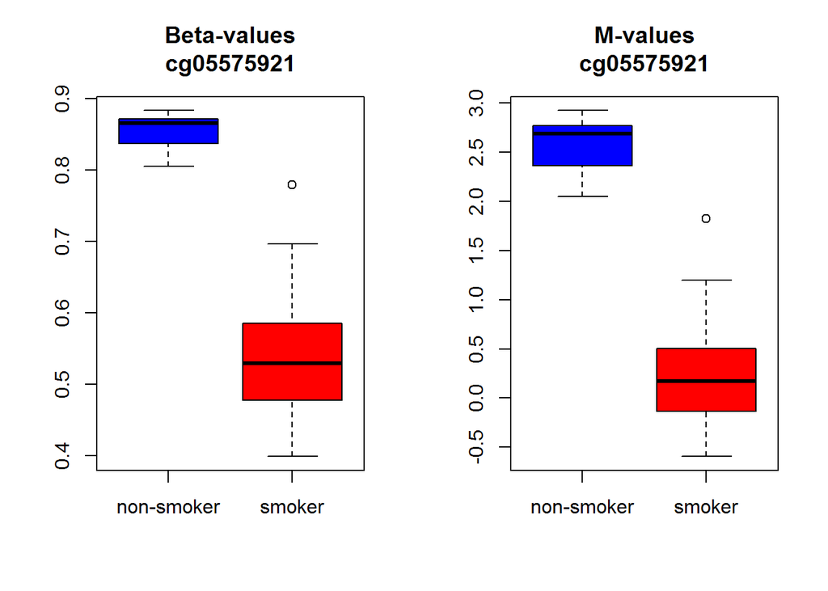

```r
par(mfrow=c(1,2))
boxplot(CpG.level  ~ smoker,data=pheno,main=paste0("Beta-values\n",CpG.name), col=c("blue","red"))
boxplot(CpG.mlevel ~ smoker,data=pheno,main=paste0("M-values\n"   ,CpG.name), col=c("blue","red"))
```

linear regression on m-values

```r
lm(CpG.mlevel ~ smoker,data=pheno) %>% summary %>% coef
```

```
##               Estimate Std. Error   t value     Pr(>|t|)
## (Intercept)   2.579071  0.1295045  19.91492 4.536452e-18
## smokersmoker -2.306816  0.1831470 -12.59544 4.712357e-13
```

We can always extract measures of the relative quality of statistical models - e.g. adjusted R2 - to look at model performance  
model on betas

```r
lm(CpG.level  ~ smoker,data=pheno) %>% summary %$% adj.r.squared
```

```
## [1] 0.8079412
```

model on mvalues

```r
lm(CpG.mlevel ~ smoker,data=pheno) %>% summary %$% adj.r.squared
```

```
## [1] 0.8446249
```

## EWAS and results using CpGassoc

```r
pheno[,smoke_dummy:=ifelse(smoker=="smoker",1,0)]

system.time(results1 <- cpg.assoc(betas.clean, pheno$smoke_dummy,fdr.cutoff=0.1))
```

```
##    user  system elapsed
##   27.63    0.80   28.53
```

there are several components of the results

```r
class(results1)
```

```
## [1] "cpg"
```

```r
names(results1)
```

```
## [1] "results"      "Holm.sig"     "FDR.sig"      "info"
## [5] "indep"        "covariates"   "chip"         "coefficients"
```

look at a few results  
here effect size is ~ mean difference in methylation proportion

```r
head(cbind(results1$coefficients[,4:5], P.value=results1$results[,3]))
```

```
##              effect.size   std.error   P.value
## cg13869341 -0.0140201941 0.020009801 0.4892933
## cg14008030 -0.0210383103 0.012591582 0.1058988
## cg12045430  0.0007836584 0.007285666 0.9151104
## cg20826792 -0.0101659309 0.010229119 0.3288206
## cg00381604  0.0076339684 0.005854633 0.2028796
## cg20253340 -0.0067290216 0.033835407 0.8437975
```

and the top hits

```r
head(cbind(results1$coefficients[,4:5], P.value=results1$results[,3])[order(results1$results[,3]),])
```

```
##            effect.size  std.error      P.value
## cg05575921  -0.3118796 0.02812176 9.343347e-12
## cg21566642  -0.2465213 0.02455116 8.790463e-11
## cg21161138  -0.1196260 0.01228767 1.733748e-10
## cg01940273  -0.1542278 0.01625089 3.014566e-10
## cg03636183  -0.1746276 0.01939830 9.291203e-10
## cg05951221  -0.1685213 0.01956379 2.325936e-09
```

check with previous result on our selected CpG (running lm without CpGassoc)

```r
cbind(results1$coefficients[,4:5],results1$results[,c(1,3)])[CpG.name,]
```

```
##            effect.size  std.error CPG.Labels      P.value
## cg05575921  -0.3118796 0.02812176 cg05575921 9.343347e-12
```

```r
summary(lm(CpG.level~smoker,pheno))
```

```
##
## Call:
## lm(formula = CpG.level ~ smoker, data = pheno)
##
## Residuals:
##       Min        1Q    Median        3Q       Max
## -0.144805 -0.027859 -0.005542  0.017396  0.236061
##
## Coefficients:
##              Estimate Std. Error t value Pr(>|t|)
## (Intercept)   0.85533    0.01989   43.01  < 2e-16 ***
## smokersmoker -0.31188    0.02812  -11.09 9.34e-12 ***
## ---
## Signif. codes:  0 '***' 0.001 '**' 0.01 '*' 0.05 '.' 0.1 ' ' 1
##
## Residual standard error: 0.07701 on 28 degrees of freedom
## Multiple R-squared:  0.8146, Adjusted R-squared:  0.8079
## F-statistic:   123 on 1 and 28 DF,  p-value: 9.343e-12
```

Bonferroni significant hits

```r
table(results1$results[,3] < 0.05/(nCpG))
```

```
##
##  FALSE   TRUE
## 470855      7
```

FDR significant hits

```r
table(results1$results[,5] < 0.05)
```

```
##
##  FALSE   TRUE
## 470847     15
```

EWAS with adjustment for cell types now we can run the linear regression on betas adjusting for cell proportions Need sex as indicator in covariate matrix

```r
results2 = cpg.assoc(
           betas.clean
          ,pheno$smoke_dummy
          ,covariates=as.data.frame(pheno[,.(sex,CD8,CD4,NK,B,MO,GR)])
          )
print(results2)
```

```
##
## The top ten CpG sites were:
##        CPG.Labels T.statistic      P.value Holm.sig        FDR
## 350188 cg05575921   -8.359051 4.044901e-08     TRUE 0.01071563
## 277487 cg21566642   -8.214066 5.378940e-08     TRUE 0.01071563
## 277488 cg01940273   -8.093834 6.827593e-08     TRUE 0.01071563
## 350212 cg21161138   -7.939355 9.301780e-08     TRUE 0.01094908
## 119741 cg05677062   -7.033653 6.079911e-07    FALSE 0.05095860
## 231789 cg03636183   -7.002815 6.493775e-07    FALSE 0.05095860
## 277486 cg05951221   -6.799513 1.005578e-06    FALSE 0.06105430
## 424615 cg02566359   -6.785137 1.037373e-06    FALSE 0.06105430
## 145236 cg01859528   -6.632908 1.444800e-06    FALSE 0.07418775
## 396224 cg14326991   -6.593294 1.575653e-06    FALSE 0.07418775
##          gc.p.value
## 350188 5.768662e-06
## 277487 7.308257e-06
## 277488 8.900609e-06
## 350212 1.147988e-05
## 119741 5.231232e-05
## 231789 5.512023e-05
## 277486 7.787326e-05
## 424615 7.980387e-05
## 145236 1.034706e-04
## 396224 1.107174e-04
##
## To access results for all  470870  CpG sites use object$results
## or sort(object)$results to obtain results sorted by p-value.
##
## General info:
##   Min.P.Observed Num.Cov fdr.cutoff FDR.method   Phenotype chipinfo
## 1   4.044901e-08       7       0.05         BH smoke_dummy     NULL
##   num.Holm num.fdr
## 1        4       4
##
## 4 sites were found significant by the Holm method
## 4 sites were found significant by BH method
##
## The beta values were taken from: betas.clean
## Effect sizes and standard error can be accessed using $coefficients
## Other attributes are: results, Holm.sig, FDR.sig, info, indep, covariates, chip
##  They can be accessed using the $
```

using mvalues

```r
results3 <- cpg.assoc(
           betas.clean
          ,pheno$smoke_dummy
          ,covariates=as.data.frame(pheno[,.(sex,CD8,CD4,NK,B,MO,GR)])
          ,logit.transform=TRUE
          )
print(results3)
```

```
##
## The top ten CpG sites were:
##        CPG.Labels T.statistic      P.value Holm.sig         FDR
## 350188 cg05575921   -9.455764 5.114336e-09     TRUE 0.002408024
## 350212 cg21161138   -8.077840 7.048685e-08     TRUE 0.011329760
## 277488 cg01940273   -8.012162 8.037072e-08     TRUE 0.011329760
## 277487 cg21566642   -7.922379 9.625187e-08     TRUE 0.011329760
## 24849  cg04763554    7.275869 3.640572e-07    FALSE 0.034282396
## 231789 cg03636183   -7.141957 4.829326e-07    FALSE 0.037897168
## 424615 cg02566359   -7.048001 5.896696e-07    FALSE 0.039662696
## 119741 cg05677062   -6.972038 6.935785e-07    FALSE 0.040820390
## 145236 cg01859528   -6.908235 7.953460e-07    FALSE 0.041608789
## 413617 cg08224975    6.734191 1.158614e-06    FALSE 0.052143844
##          gc.p.value
## 350188 8.980238e-07
## 350212 8.247812e-06
## 277488 9.194770e-06
## 277487 1.067194e-05
## 24849  3.160339e-05
## 231789 3.967407e-05
## 424615 4.655966e-05
## 119741 5.300504e-05
## 145236 5.911354e-05
## 413617 7.965853e-05
##
## To access results for all  470870  CpG sites use object$results
## or sort(object)$results to obtain results sorted by p-value.
##
## General info:
##   Min.P.Observed Num.Cov fdr.cutoff FDR.method   Phenotype chipinfo
## 1   5.114336e-09       7       0.05         BH smoke_dummy     NULL
##   num.Holm num.fdr
## 1        4       9
##
## 4 sites were found significant by the Holm method
## 9 sites were found significant by BH method
##
## The beta values were taken from: betas.clean
## Effect sizes and standard error can be accessed using $coefficients
## Other attributes are: results, Holm.sig, FDR.sig, info, indep, covariates, chip
##  They can be accessed using the $
```

## Genomic inflation in EWAS

qqplot and lambda interpretation

```r
par(mfrow=c(1,1))
plot(results1, main="QQ plot for association between methylation and Smoking\nadjusted for cell proportions")
```

[figure not shown]

```r
plot(results2, main="QQ plot for association between (mvals) methylation and Smoking\nadjusted for cell proportions")
```

[figure not shown]

Lambda - this is a summary measure of genomic inflation  
ratio of observed vs expected median p-value - is there early departure of the qqline estimated at -log10(median=0.5) ~ 0.3 on the x-axis of a qqplot

```r
lambda <- function(p) median(qchisq(p, df=1, lower.tail=FALSE), na.rm=TRUE) / qchisq(0.5, df=1)
```

Lambda before cell type adjustment

```r
lambda(results1$results[,3])
```

```
## [1] 1.595985
```

Lambda after cell type adjustment

```r
lambda(results2$results[,3])
```

```
## [1] 1.849664
```

```r
datamanhat = cbind(results2$results,results2$coefficients)
setDT(datamanhat)
datamanhat = datamanhat[,.(probe_id=CPG.Labels,effect.size,std.error,P.value)]

datamanhat = merge(datamanhat,manifest[,.(probe_id,chr,mapinfo)],by="probe_id")
```

See where the top hits are

```r
datamanhat[order(P.value)][1:7]
```

```
##      probe_id effect.size   std.error      P.value chr   mapinfo
## 1: cg05575921  -0.2842688 0.034007305 4.044901e-08   5    373378
## 2: cg21566642  -0.2370810 0.028862804 5.378940e-08   2 233284661
## 3: cg01940273  -0.1481128 0.018299456 6.827593e-08   2 233284934
## 4: cg21161138  -0.1090926 0.013740742 9.301780e-08   5    399360
## 5: cg05677062  -0.0606065 0.008616647 6.079911e-07  12 123874707
## 6: cg03636183  -0.1545967 0.022076368 6.493775e-07  19  17000585
## 7: cg05951221  -0.1589150 0.023371529 1.005578e-06   2 233284402
```

Volcano Plot-results2 Bonferroni threshold

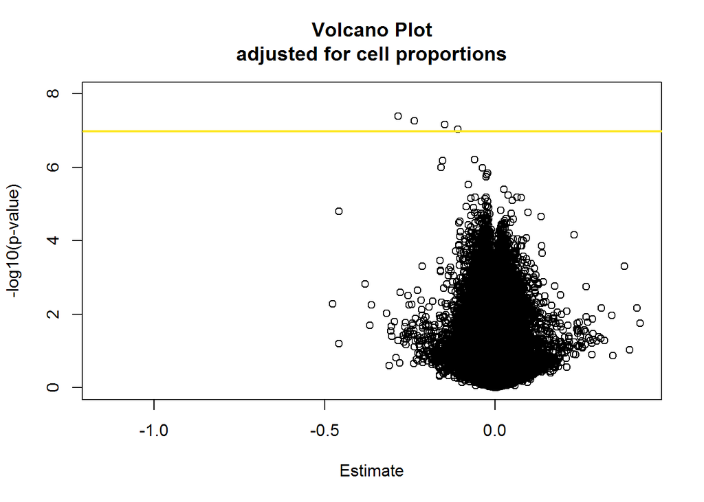

```r
plot(-log10(P.value) ~ effect.size,data=datamanhat,xlab="Estimate",ylab="-log10(p-value)",main="Volcano Plot\nadjusted for cell proportions",ylim=c(0,8))
abline(h = -log10(0.05/(nCpG)), lty=1, col="#FDE725FF", lwd=2)
```

## Manhattan plot for cell-type adjusted EWAS

Cast the variable chr (so we can simplify and use a numeric x-axis)

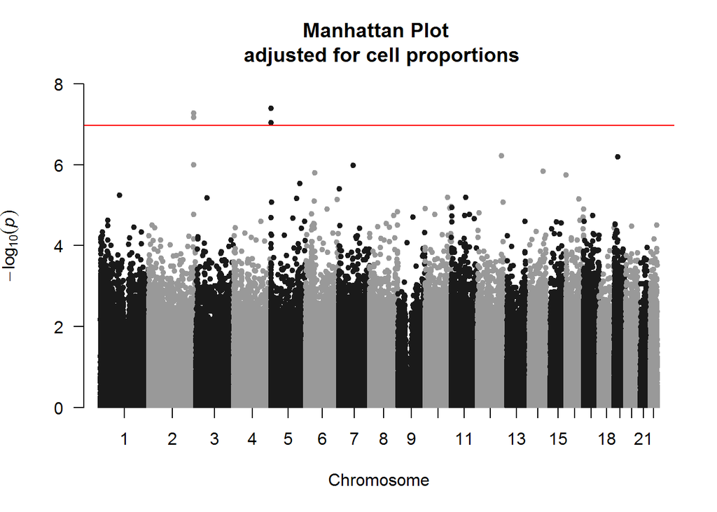

```r
datamanhat[,chr:=as.integer(chr)]

qqman::manhattan(datamanhat,chr="chr",bp="mapinfo",p="P.value",snp="probe_id"
   ,suggestiveline=FALSE, genomewideline = -log10(0.05/(nCpG)),ylim=c(0,8)
   ,main = "Manhattan Plot \n adjusted for cell proportions")
```

cleanup

```r
rm(nCpG,CpG.name,datamanhat,lambda,results1,results2,results3)
gc()
```

```
##            used  (Mb) gc trigger   (Mb)  max used   (Mb)
## Ncells 10589950 565.6   15499525  827.8  15499525  827.8
## Vcells 53298413 406.7  156171135 1191.5 156164088 1191.5
```

End of script 02